# Nielsen Analysis

Daniel O’Leary

4/05/2021

# 1 Background

Unhealthy eating and eating-related diseases are major public health issues in the United States and around the world.

In this analysis, we will use several machine learning models to predict the healthfulness of a household’s calorie consumption.

The data we use in this analysis come from several sources. The primary data source is the NielsenIQ HomeScan Consumer Panel Dataset. The Consumer Panel Data comprise a nationally representative panel of households that continually provide information about their purchases in a longitudinal study in which panelists stay on as long as they continue to meet NielsenIQ’s criteria. NielsenIQ consumer panelists use in-home scanners to record all of their purchases (from any outlet) intended for personal, in-home use. Consumers provide information about their households and what products they buy.

The outcome we will try to predict is the healthfulness of a household’s calorie consumption. In order to create this outcome, we used to additional sources of data. First, we used data from Label Insights that provides UPC-level nutrition label data. For our purposes, we were interested in the number of calories in each food product purchased by each household. We join this data to the NielsenIQ data using UPC’s. In addition, we use crosswalk from the United States Department of Agriculture that matches each UPC to one of 52 food categories in the Quarterly Food-at-Home Price Database. We then classify each of these food categories as healthy or not using guidelines provided by Volpe, Okrent, & Leibtag (2013). We then calculate the healthfulness of a household’s calorie consumption by calculating the percentage of all calories that come from healthy food categories.

Predicting this outcome might be useful for stakeholders who want to determine where they might direct efforts to improve diet.

# 2 Setup

## 2.1 Load packages

```r
if (!require("pacman")) install.packages("pacman")
pacman::p_load(
  tidyverse,
  tidymodels,
  haven,
  GGally,
  caret,
  ranger,
  glmnet,
  randomForest,
  gbm,
  xgboost,
  vip
)
```

## 2.2 Load data

```r
source("G:/My Drive/research/projects/niel/code_archive/small_dataset_selection.R")
```

# 3 Preliminaries

## 3.1 Glimpse of the data

First, let’s take a look at the data.

```r
data %>%
  glimpse()
```

```
## Rows: 19,859
## Columns: 19
## $ yes_scale                          <dbl> 0.6973027, 1.0130187, -1.5558202, 0~
## $ income                             <dbl> 26, 26, 16, 27, 21, 18, 26, 23, 26,~
## $ Male_Head_Education                <dbl> 6, 3, 4, 6, 5, 3, 5, 4, 5, 6, 5, 6,~
## $ Female_Head_Education              <dbl> 5, 3, 3, 5, 2, 5, 5, 5, 5, 5, 5, 5,~
## $ Male_Head_Employment               <fct> 9, 3, 3, 3, 9, 9, 3, 3, 3, 3, 9, 3,~
## $ Female_Head_Employment             <fct> 9, 2, 3, 1, 9, 3, 9, 3, 3, 1, 2, 9,~
## $ Male_Head_Age                      <dbl> 9, 4, 3, 9, 9, 8, 5, 8, 7, 8, 8, 9,~
## $ Female_Head_Age                    <dbl> 8, 3, 3, 9, 9, 8, 5, 8, 6, 7, 8, 9,~
## $ household_size                     <dbl> 2, 4, 4, 2, 2, 2, 6, 2, 3, 2, 3, 3,~
## $ Marital_Status                     <fct> 1, 1, 3, 1, 1, 1, 1, 1, 1, 1, 1, 1,~
## $ Race                               <fct> 2, 1, 1, 1, 1, 1, 1, 1, 1, 1, 1, 3,~
## $ median_income_county               <dbl> 79619, 55634, 44680, 50273, 48140, ~
## $ median_home_value_county           <dbl> 556900, 189700, 141600, 166100, 154~
## $ median_monthly_housing_cost_county <dbl> 1653, 970, 833, 844, 803, 1253, 817~
## $ land_area_2010                     <dbl> 430.50, 253.70, 1411.29, 542.43, 32~
## $ total_pop_county                   <dbl> 939406, 35394, 29347, 354589, 10455~
## $ gini_county                        <dbl> 0.5350, 0.3989, 0.4101, 0.4854, 0.4~
## $ physicians_scale                   <dbl> 3.52934369, -0.01747046, -0.9468312~
## $ reference_group_income             <dbl> 0.4283707, 0.6256947, 0.6098902, 0.~
```

Note that the full dataset we usually use for this analysis has over 2 million observations and is run on a computing cluster, but we’ve downsized it to around 20,000 observations for this analysis.

## 3.2 Various distributions

Let’s take a look at the distribution of each variable. At the moment, I’m not really worried about relationships between variables in part because we will take steps to deal with multicollinearity later in this analysis. It’s also kind of tough to visualize an 18 by 18 grid in R.

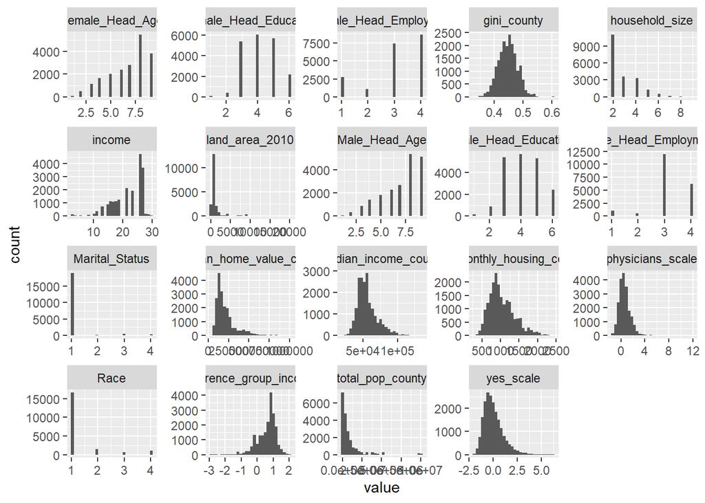

```r
data %>%
  mutate(across(everything(), as.numeric)) %>%
  pivot_longer(
    cols = everything()
  ) %>%
  ggplot(aes(value)) +
  geom_histogram() +
  facet_wrap(~ name, scales = "free")
```

Marital Status and Race are factor variables, so we won’t worry about them for now.

It looks like it might be worth applying a log transform to land area, median home value, median monthly housing cost, and total population of the county.

Income is already on a scale that applies a kind of transform.

Fortunately, the distribution of our outcome looks relatively normal.

# 4 Random Forest using the tidymodels package

## 4.1 Split data into training and test set

```r
set.seed(1234)

# Split data
data_split <- initial_split(data, prop = 0.75)

# Create training and test datasets
training_data <- training(data_split)
testing_data  <- testing(data_split)
```

## 4.2 Create out cross-validation folds

```r
set.seed(1234)
folds <- vfold_cv(training_data, v = 10)
folds
```

```
## #  10-fold cross-validation
## # A tibble: 10 x 2
##    splits               id
##    <list>               <chr>
##  1 <split [13404/1490]> Fold01
##  2 <split [13404/1490]> Fold02
##  3 <split [13404/1490]> Fold03
##  4 <split [13404/1490]> Fold04
##  5 <split [13405/1489]> Fold05
##  6 <split [13405/1489]> Fold06
##  7 <split [13405/1489]> Fold07
##  8 <split [13405/1489]> Fold08
##  9 <split [13405/1489]> Fold09
## 10 <split [13405/1489]> Fold10
```

## 4.3 Specify the type of model to run

Here we will try a random forest and we will use the ranger package which is much faster than randomForest. Note that we can and will parallelize the training of this model.

```r
cores <- parallel::detectCores() - 6

rf_mod <-
  rand_forest(mtry = tune(), min_n = tune(), trees = 1000) %>%
  set_engine("ranger", num.threads = cores) %>%
  set_mode("regression")
```

## 4.4 Specify a model recipe

Next we will specify a model recipe which will include our model formula and will also pre-process all of our data, including a step that runs PCA on certain predictors.

```r
rf_recipe <-
  recipe(yes_scale ~ ., data = training_data) %>%
  step_dummy(all_nominal()) %>%
  step_log(land_area_2010, total_pop_county, contains("median")) %>%
  step_center(all_predictors()) %>%
  step_scale(all_predictors()) %>%
  step_pca(contains("county"), contains("Education"), contains("Age"), contains("Employment"), threshold = .75) %>%
  step_nzv(all_predictors())
```

### 4.4.1 Check out some of what this recipe does

```r
rf_data_trained <-
  prep(
    rf_recipe,
    training_data,
    verbose = TRUE
  )
```

```
## oper 1 step dummy [training]
## oper 2 step log [training]
## oper 3 step center [training]
## oper 4 step scale [training]
## oper 5 step pca [training]
## oper 6 step nzv [training]
## The retained training set is ~ 79.18 Mb  in memory.
```

```r
rf_data_trained
```

```
## Data Recipe
##
## Inputs:
##
##       role #variables
##    outcome          1
##  predictor         18
##
## Training data contained 14894 data points and no missing data.
##
## Operations:
##
## Dummy variables from Male_Head_Employment, ... [trained]
## Log transformation on land_area_2010, ... [trained]
## Centering for income, ... [trained]
## Scaling for income, ... [trained]
## PCA extraction with median_income_county, ... [trained]
## Sparse, unbalanced variable filter removed Marital_Status_X2, ... [trained]
```

```r
rf_data_trained %>%
  juice()
```

```
## # A tibble: 14,894 x 13
##    income household_size land_area_2010 physicians_scale reference_group_income
##     <dbl>          <dbl>          <dbl>            <dbl>                  <dbl>
##  1  0.241         -0.730        -0.774           -0.267                 -0.698
##  2 -0.141         -0.730         0.252           -0.373                 -2.42
##  3  0.815         -0.730        -0.224           -0.605                  1.15
##  4 -0.524          1.81          0.276            0.235                  0.866
##  5 -0.141          0.116         1.28            -0.823                  0.140
##  6 -0.715          0.116         2.72             0.244                 -1.18
##  7  0.815         -0.730         0.0607          -1.66                   1.04
##  8 -0.524         -0.730        -0.342            0.0550                -1.58
##  9  0.815         -0.730        -0.309           -0.0815                 0.0774
## 10  1.01          -0.730        -0.0459          -0.355                 -0.761
## # ... with 14,884 more rows, and 8 more variables: yes_scale <dbl>,
## #   Race_X2 <dbl>, PC1 <dbl>, PC2 <dbl>, PC3 <dbl>, PC4 <dbl>, PC5 <dbl>,
## #   PC6 <dbl>
```

The PCA reduce the number of variables from 19 to 13.

## 4.5 Specify workflow

Next we will create a workflow which is basically just an object that combines our pre-processing and modeling.

```r
rf_workflow <-
  workflow() %>%
  add_model(rf_mod) %>%
  add_recipe(rf_recipe)
```

## 4.6 Tune hyperparameters

Next, we will use cross-validation to identify the hyperparameters that give us the best model fit.

```r
rf_res <-
  rf_workflow %>%
  tune_grid(
    folds,
    grid = 25,
    control = control_grid(save_pred = TRUE),
    metrics = metric_set(rsq)
  )
```

```
## i Creating pre-processing data to finalize unknown parameter: mtry
```

## 4.7 Best set of hyperparameters

```r
rf_res %>%
  collect_metrics() %>%
  arrange(desc(mean))
```

```
## # A tibble: 25 x 8
##     mtry min_n .metric .estimator   mean     n std_err .config
##    <int> <int> <chr>   <chr>       <dbl> <int>   <dbl> <chr>
##  1     1    18 rsq     standard   0.0564    10 0.00544 Preprocessor1_Model19
##  2     1    35 rsq     standard   0.0556    10 0.00477 Preprocessor1_Model11
##  3     2    40 rsq     standard   0.0538    10 0.00490 Preprocessor1_Model08
##  4     3     8 rsq     standard   0.0517    10 0.00520 Preprocessor1_Model20
##  5     3    22 rsq     standard   0.0515    10 0.00502 Preprocessor1_Model22
##  6     5    32 rsq     standard   0.0503    10 0.00475 Preprocessor1_Model21
##  7     4    14 rsq     standard   0.0501    10 0.00496 Preprocessor1_Model12
##  8     6    24 rsq     standard   0.0501    10 0.00500 Preprocessor1_Model18
##  9     4    12 rsq     standard   0.0500    10 0.00496 Preprocessor1_Model13
## 10     5    19 rsq     standard   0.0498    10 0.00478 Preprocessor1_Model04
## # ... with 15 more rows
```

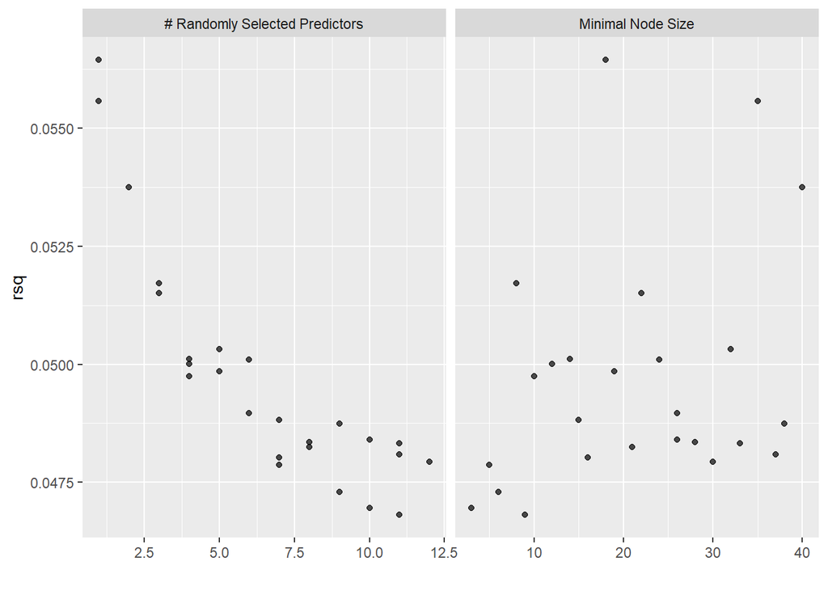

```r
autoplot(rf_res)
```

```r
rf_best <-
  rf_res %>%
  select_best(metric = "rsq")

rf_best
```

```
## # A tibble: 1 x 3
##    mtry min_n .config
##   <int> <int> <chr>
## 1     1    18 Preprocessor1_Model19
```

# 5 Final Random Forest Model

```r
final_mod <-
  rand_forest(mtry = 1, min_n = 12, trees = 1000) %>%
  set_engine("ranger", num.threads = cores, importance = "impurity") %>%
  set_mode("regression")

final_mod_workflow <-
  rf_workflow %>%
  update_model(final_mod)

final_fit <-
  final_mod_workflow %>%
  last_fit(data_split)

final_fit %>%
  collect_metrics()
```

```
## # A tibble: 2 x 4
##   .metric .estimator .estimate .config
##   <chr>   <chr>          <dbl> <chr>
## 1 rmse    standard      0.988  Preprocessor1_Model1
## 2 rsq     standard      0.0470 Preprocessor1_Model1
```

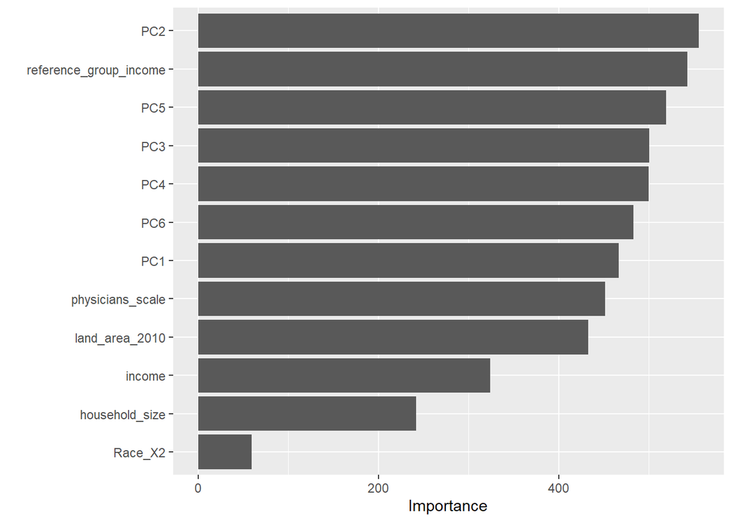

```r
final_fit %>%
  pluck(".workflow", 1) %>%
  pull_workflow_fit() %>%
  vip(num_features = 20)
```

# 6 Elastic-Net using the tidymodels packages

## 6.1 Specify the type of model to run and the model recipe

```r
elnet_mod <-
  linear_reg(penalty = tune(), mixture = tune()) %>%
  set_engine("glmnet") %>%
  set_mode("regression")

elnet_recipe <-
  recipe(yes_scale ~ ., data = training_data) %>%
  step_dummy(all_nominal()) %>%
  step_log(land_area_2010, total_pop_county, contains("median")) %>%
  step_center(all_predictors()) %>%
  step_scale(all_predictors()) %>%
  step_nzv(all_predictors())
```

## 6.2 Create workflow object

```r
elnet_workflow <-
  workflow() %>%
  add_model(elnet_mod) %>%
  add_recipe(elnet_recipe)
```

## 6.3 Tune hyperparameters

```r
mixture_param <- parameters(penalty(), mixture())
regular_grid <- grid_regular(mixture_param, levels = c(5, 5))

# mixture = alpha
elnet_res <-
  elnet_workflow %>%
  tune_grid(
    folds,
    grid = regular_grid,
    control = control_grid(save_pred = TRUE),
    metrics = metric_set(rsq)
  )
```

[output not shown]

[output not shown]

[output not shown]

[output not shown]

[output not shown]

[output not shown]

[output not shown]

[output not shown]

[output not shown]

[output not shown]

## 6.4 Best set of hyperparameters

```r
elnet_res %>%
  collect_metrics() %>%
  arrange(desc(mean))
```

```
## # A tibble: 25 x 8
##        penalty mixture .metric .estimator   mean     n std_err .config
##          <dbl>   <dbl> <chr>   <chr>       <dbl> <int>   <dbl> <chr>
##  1    3.16e- 3    0.25 rsq     standard   0.0528    10 0.00384 Preprocessor1_Mo~
##  2    3.16e- 3    0.5  rsq     standard   0.0528    10 0.00384 Preprocessor1_Mo~
##  3    1   e-10    0    rsq     standard   0.0528    10 0.00384 Preprocessor1_Mo~
##  4    3.16e- 8    0    rsq     standard   0.0528    10 0.00384 Preprocessor1_Mo~
##  5    1   e- 5    0    rsq     standard   0.0528    10 0.00384 Preprocessor1_Mo~
##  6    3.16e- 3    0    rsq     standard   0.0528    10 0.00384 Preprocessor1_Mo~
##  7    1   e-10    0.75 rsq     standard   0.0527    10 0.00383 Preprocessor1_Mo~
##  8    3.16e- 8    0.75 rsq     standard   0.0527    10 0.00383 Preprocessor1_Mo~
##  9    1   e- 5    0.75 rsq     standard   0.0527    10 0.00383 Preprocessor1_Mo~
## 10    1   e-10    1    rsq     standard   0.0527    10 0.00383 Preprocessor1_Mo~
## # ... with 15 more rows
```

```r
# elnet_res %>%
#   collect_metrics() %>%
#   ggplot(aes(penalty, mean)) +
#   geom_point() +
#   facet_wrap(~ mixture, scales = "free")
```

```r
elnet_best <-
  elnet_res %>%
  select_best(metric = "rsq")

elnet_best
```

```
## # A tibble: 1 x 3
##   penalty mixture .config
##     <dbl>   <dbl> <chr>
## 1 0.00316    0.25 Preprocessor1_Model09
```

## 6.5 Final Elastic Net Model

```r
final_mod <-
  linear_reg(penalty = 0.003162278, mixture = 0.5) %>%
  set_engine("glmnet") %>%
  set_mode("regression")

final_mod_workflow <-
  elnet_workflow %>%
  update_model(final_mod)

final_fit <-
  final_mod_workflow %>%
  last_fit(data_split)

final_fit %>%
  collect_metrics()
```

```
## # A tibble: 2 x 4
##   .metric .estimator .estimate .config
##   <chr>   <chr>          <dbl> <chr>
## 1 rmse    standard      0.989  Preprocessor1_Model1
## 2 rsq     standard      0.0439 Preprocessor1_Model1
```

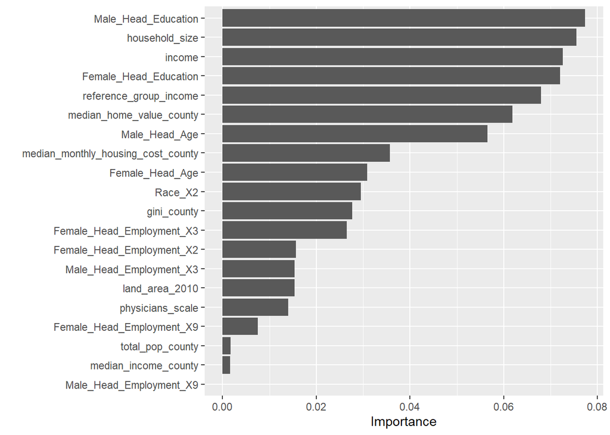

```r
final_fit %>%
  pluck(".workflow", 1) %>%
  pull_workflow_fit() %>%
  vip(num_features = 20)
```

# 7 Comments

Looks like random forest wins the day, but both models are honestly not very good at predicting this outcome. May want to rethink the predictors we include.